# Aside

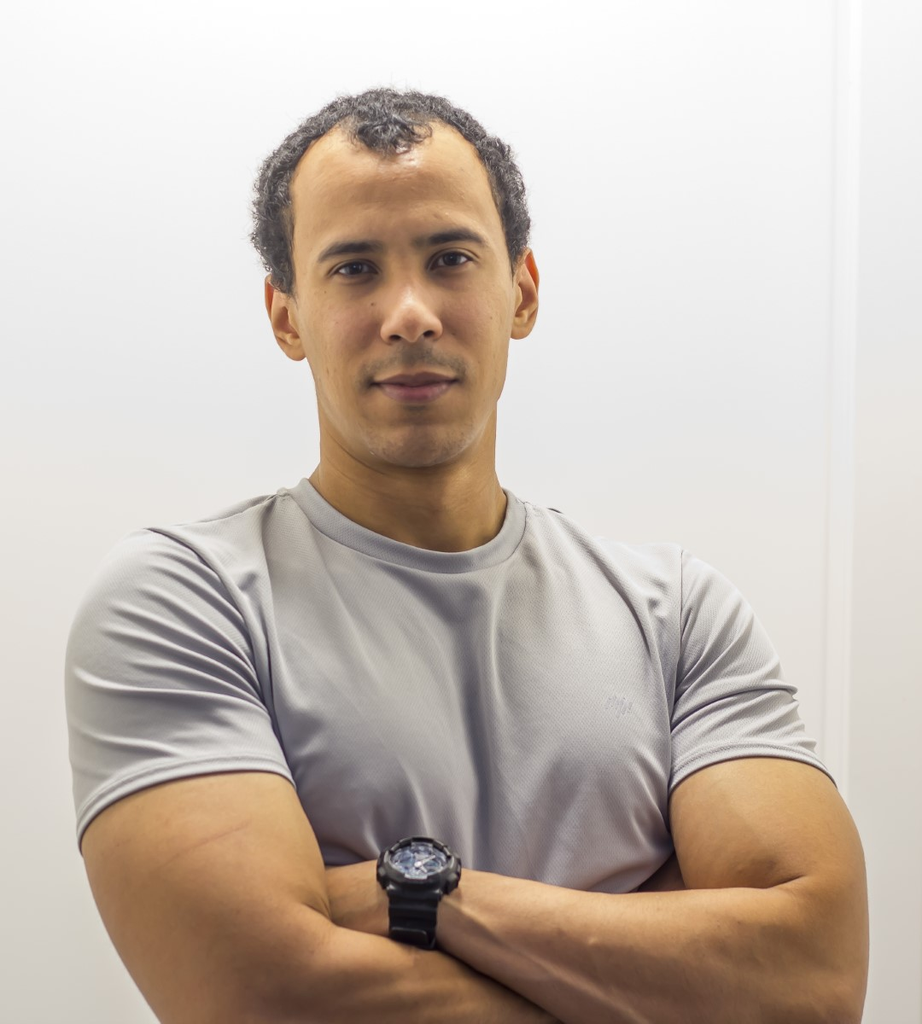

## Contact

- juansa@uvic.ca
- juan_sanar
- juansanar
- juansanar.com
- juancsanchezarias

[CV’s PDF version](https://www.juansanar.com/files/juansanar_cv.pdf)

## Technical Skills

Project Management

Scientific Writing

Microscopy

Cell culture

Bio-image analysis

Biostatistics

R

Python

Bash

MATLAB

## Disclaimer

Made with the R package [**pagedown**](https://github.com/rstudio/pagedown).

Source code forked from nstrayer/datadrivencv and available at juansanar/datadrivencv.

Last updated on 2022-07-03.

# Main

## Juan C. Sanchez-Arias, MD, PhD

Trained as medical doctor and neuroscientist, I use my expertise in neurobiology, computational biology, and experimental design to magnify the impact of [BenchSci’s](https:///www.benchsci.com/) platform and mission to empower scientists to improve the speed and quality of preclinical research with the most advanced biomedical AI.

## Education

### Doctor of Philosophy in Neuroscience

University of Victoria - Division of Medical Sciences

Victoria, BC, Canada

2020 - 2015

- **Dissertation:** Pannexin 1 regulates dendritic spine formation.
- **Relevant coursework:** Developmental neurobiology, Tools for the study of ion channels.
- **GPA:** 8.2/9.0.

### Doctor of Medicine (Médico y Cirujano)

Universidad del Valle - School of Medicine

Cali, Valle, Colombia

2014 - 2007

- **Pre-Diploma Rotatory Internship:** Hospital Universitario del Valle ESE ‑ Universidad del Valle. Cali, Valle. Colombia.
- **Research Internship:** Centro de Estudios Cerebrales (Centre for Brain Studies). Universidad del Valle. Cali, Valle. Colombia.
- **Observership:** Functional Neurosurgery. Department of Neurosurgery. University of Illinois Hospital & Health Sciences System. University of Illinois at Chicago. Chicago, IL. USA. Supervisor: Dr. Konstantin Slavin.
- **Professional elective:** Neurosurgery and Neurocritical Care. Department of Neurosurgery.Hospital Universitario del Valle ESE ‑ Universidad del Valle. Cali, Valle. Colombia.
- **Relevant Coursework:** Functional Neuroanatomy, Cerebral cortex cytoarchitectonics, Scientific Integrity, Biostatistics, Toxicology & Pharmacodependence, Systems Pathology. **GPA**: 4.4/5.0

## Industry Experience

### Scientific Associate (Experimental Data)

BenchSci

Remote

Current - 2022

- Envision and evaluate features to improve BenchSci’s platform and future roadmap using scientific insights.
- Work in collaboration with Product and Engineering teams to magnify the impact and applications of BenchSci’s platform.
- Work in collaboration with R&D to improve the data processing cycle within BenchSci’s platform.

## Research Experience

### Postdoctoral Fellow

Division of Medical Sciences

University of Victoria

2022 - 2020

- **Advisors:** Leigh Anne Swayne, PhD; Laura Arbour MSc, MD,
- **Area of study:** ankyrin adapter proteins, ion channels, calcium and voltage dysregulation in cardiomyocytes and neurons with ankyrin variants.
- Community medical genetics in inherited arrhythmias.
- Cardiomyocyte and neuronal calcium homeostasis
- Bioinformatics and computational modelling of cardiomyocyte physiology.

### Graduate Research Assistant

Division of Medical Sciences

University of Victoria

2020 - 2015

- **Advisor:** Leigh Anne Swayne, PhD.
- **Area of study:** Pannexin 1 channels, dendritic spine plasticity, synapse formation, channel trafficking, neuronal cytoskeleton dynamics, neural stem cells, advanced microscopy for cell biology.
- Generated conditional and conditional‑inducible knockout models for the study of cerebral cortex development.
- Optimized protocols to generate primary neuronal cultures from neonatal mice suitable for network analysis.
- Developed methods to visualize dendritic spines and filopodia in tissue sections and living primary neurons.

### Research Medical Intern

Centro de Estudios Cerebrales

Universidad del Valle

2014 - 2013

- **Advisors:** Martha Escobar, MSc; Hernán Pimienta, MSc, Efrain Buritica, PhD.
- **Area of study:** functional neuroanatomy, cerebral cortex organization, traumatic brain injury, stroke, neuroprotection.
- Performed carotid ligation in Wistar rats using microsurgery techniques.
- Investigated diffuse traumatic brain injury using a weight-drop model, organotypic rat rain brain slices. fluorescent immunochemistry and microscopy.

### Undergraduate Medical Researcher

School of Public Health

Universidad del Valle

2011 - 2010

- **Advisors:** Enrique A. Estevez, MD and Elsa P. Muñoz, MD, MPH
- **Area of study:** Cardiovascular risk factor assessment in spinal cord injured patient assisting to a tertiary‑level hospital.
- Prepared a research project proposal, liaised with ethical boards, and established a network of collaborators to complete a standardized and regional survey in cardiovascular health.
- Led data management and prepared reports and presentations to share project results in local and national meetings.
- Contributed to the assessment and management of patients with chronic spinal cord injury, including prescribing rehabilitation plans and ordering of radiological and laboratory ancillary tests. Discussed cases with Physical Medicine and Rehabilitation attendings and residents.

#### Research interests

Translational research

Bio-image analysis

Neuronal and cardiac physiology

Bioinformatics

Clinical genetics

Open science.

#### Teaching philosophy

I strive to foster an active learning and respectful environment for students in which each student has equal opportunity to exchange ideas and ask questions. I believe that discussing ideas is key for developing critical thinking, communication skills, and an inquisitive mind; while providing immediate feedback on students’ understanding of the discussed topic.

#### Society memberships

Canadian Society for Molecular Bioscience

Canadian Cardiovascular Society

Canadian Association of Neuroscience

Society for Neuroscience

Colegio Colombiano de Neurociencias - COLNE

## Teaching Experience

### Foundations of Medical Practice I and II

Island Medical Program

University of Victoria

2020 - 2017

- **Courses:** MEDD412 (Year 1), MEDD421 (Year 2), MEDD422 (Year 2).
- TA for Neuroanatomy Bootcamp and Laboratories.
- **Subjects:** Cranial Nerves V & VII and Pain, Eye Movements and Brainstem, Cerebral Cortex, Functional Areas, and Blood Supply, Control of Movement and Cerebellum, Limbic System/Dementia

## Service & Leadership

### Who Can Become a Scientist?

Co-founder and Co-organizer

University of Victoria

Current - 2021

- [“Who can become a scientist?”](https://www.whocanbeascientist.org/) is a symposium for a high school age audience that discusses equity, diversity, and inclusion issues in science.
- It reflects on the stereotypical image of scientists and the importance of leveraging support from role models and mentors to increase diversity in STEM.

### Let’s Talk Science

University of Victoria

Victoria, BC, Canada

2022 - 2018

- Contribute to Neuroscience Outreach talks and high school science excursions at the University of Victoria ‑ Division of Medical Sciences.

### CIHR Brain Bee

Victoria Chapter

Victoria, BC, Canada

2022 - 2017

- Organize and coordinate social media for the Victoria Brain Bee. Mentored high school students from the Greater Victoria Area who participated in the Brain Bee competition
- Secure funding to sponsor Victoria Brain Bee winners traveling to the CIHR National Brain Bee.

### Neuroscience Graduate Student Association (NGSA)

University of Victoria

Victoria, BC, Canada

2020 - 2017

### BCREGMED Newsletter

Co-editor

BCREGMED

2019 - 2017

- Involved in BC Regenerative Medicine Symposium organization, recruiting speakers and sponsors, and evaluating abstract submissions and posters.
- Involved in brainstorming and organizing workshops for trainees.

#### Selected presentations

**2021**

**COLNE - Tertulia Metodologica** | Flujos de Trabajo para Analisis de Imagenes Adquiridas por Microscopia (Bio-image analysis workflows) | *Talk*

**SfN Global Connectome 2021** | Pannexin 1 regulates dendritic protrusion dynamics in developing cortical neurons | *Poster*

**2020**

**University of British Columbia 2<sup>nd</sup> Annual Tri‑Cluster Research Day: The Future of Health** | Pannexin 1 regulates dendritic protrusion dynamic in developing cortical neurons | *Talk*

**2019**

**International Gap Junction Conference** | Pannexin 1 regulates neuronal networks and dendritic spine formation in cortical neurons | *Star Award Talk*

**Canadian Association of Neuroscience Meeting** | Pannexin 1 regulates network ensembles and dendritic spine development in cortical somatosensory neurons | *Poster*

**2018**

**Society for Neuroscience** | Pannexin 1 regulates somatosensory pyramidal neuron dendritic spine density and sensorimotor function | *Poster*

**2017**

**BC Regenerative Medicine Symposium** | Pannexin 1 regulates cortical dendritic spine formation | *Talk*

**2015**

**Canadian Association of Neuroscience Meeting** | Investigation of Pannexin 1 in the response of developing neurons to stroke | *Poster*

## Awards

### Research Trainee Award

Michael Smith Foundation for Health Research

N/A

2024 - 2021

- Project: [The impact of the loss-of-function ankyrin-B p.S646F variant on cardiomyocyte and neuronal excitability: Implications for diagnosis and treatment of heart disease](https://www.msfhr.org/1/award/the-impact-of-the-loss-of-function-ankyrin-b-p-s646f-variant-on-cardiomyocyte-and-neuronal-excitability-implications-for-diagnosis-and-treatment-of-heart-disease/).

### NB Gilula Star Award

International Gap Junction Conference

N/A

2019 - 2019

- Star Award and lecture for top-ranked abstracts.

### John & Myrtle Tilley Graduate Scholarship

University of Victoria - Faculty of Graduate Studies

N/A

2019 - 2019

### Vera Allen Travel Award for Medical Sciences,

University of Victoria - Faculty of Graduate Studies

N/A

2019 - 2016

### James A. & Laurette Agnew Memorial Scholarship & Award

University of Victoria - Faculty of Graduate Studies

N/A

2019 - 2015

### BC Regenerative Medicine Travel Award

BC Regenerative Medicine Network

N/A

2018 - 2018

### Donald Wagg Graduate Scholarship

University of Victoria - Faculty of Graduate Studies

N/A

2018 - 2017

### University of Victoria Graduate Award

University of Victoria - Faculty of Graduate Studies

N/A

2017 - 2015

### University of Victoria Student Travel Grant

University of Victoria - Faculty of Graduate Studies

N/A

2016 - 2016

### University of Victoria Fellowship Entrance Award

University of Victoria - Faculty of Graduate Studies

N/A

2015 - 2015

### School of Medicine Dean’s List

Universidad del Valle ‑ School of Medicine

N/A

2014 - 2007

- Years awarded: 2007, 2009, 2013, 2014

### Valle del Cauca Public High School Academic Excellence Scholarship

Infivalle-Colombia

N/A

2007 - 2006

## Publications

### A systematic, open‑science framework for quantification of cell‑types in mouse brain sections using fluorescence microscopy

Frontiers in Neuroanatomy

N/A

2021 - 2021

- **Juan C. Sanchez‑Arias**, Michael Carrier, Simona D. Frederiksen, Olga Shevtsova, Chloe Mckee, Emma van der Slagt, Elisa Gonçalves De Andrade, Hai Lam Nguyen, Penelope A. Young, Marie‑Ève Tremblay, Leigh Anne Swayne.
- DOI: 10.3389/fnana.2021.722443.
- Type: Original research article.

### Purinergic signaling in nervous system health & disease: Focus on pannexin 1

Pharmacology & Therapeutics

N/A

2021 - 2021

- **Juan C. Sanchez‑Arias**, Emma Slagt, Haley A. Vecchiarelli, Rebecca C. Candlish, Nicole York, Penelope A. Young, Olga Shevtsova, Afnan Juma, Marie‑Ève Tremblay, Leigh Anne Swayne.
- DOI: 10.1016/j.pharmthera.2021.107840.
- Type: Review article.

### ATP Triggers Macropinocytosis That Internalizes and Is Regulated by PANX1

bioRxiv

N/A

2020 - 2020

- Andrew K. J. Boyce, Emma Slagt, **Juan C. Sanchez‑Arias**, Leigh Anne Swayne.
- DOI: 10.1101/2020.11.19.389072.
- Type: Original research article.

### Pannexin 1 Regulates Dendritic Protrusion Dynamics in Immature Cortical Neurons

eNeuro

N/A

2020 - 2020

- **Juan C. Sanchez‑Arias**, Rebecca C. Candlish, Emma Slagt, Leigh Anne Swayne.
- DOI: 10.1523/ENEURO.0079-20.2020.
- Type: Original research article.

### PANX1 in Inflammation Heats up: New Mechanistic Insights with Implications for Injury and Infection

Cell Calcium

N/A

2020 - 2020

- **Juan C. Sanchez‑Arias**, Leigh E. Wicki‑Stordeur, Rebecca C. Candlish, Emma Slagt, Irina Paci, Praveen P. N. Rao, Brian A. MacVicar, Leigh Anne Swayne.
- DOI: 10.1016/j.ceca.2020.102253.
- Type: Review article.

### Consideration of Pannexin 1 Channels in COVID‑19 Pathology and Treatment

American Journal of Physiology‑Lung Cellular and Molecular Physiology

N/A

2020 - 2020

- Leigh Anne Swayne, Scott R. Johnstone, Chen Seng Ng, **Juan C. Sanchez‑Arias**, Miranda E. Good, Silvia Penuela, Alexander W. Lohman, Abigail G. Wolpe, Victor E. Laubach, Michael Koval, Brant E. Isakson.
- DOI: 10.1152/ajplung.00146.2020.
- Type: Perspective article.

### Ankyrin‑B p.S646F undergoes increased proteasome degradation and reduces cell viability in the H9c2 rat ventricular cardiomyoblast cell line

Biochemistry & Cell Biology

N/A

2020 - 2020

- Lena Chen, Catherine S. W. Choi, **Juan C. Sanchez‑Arias**, Laura T. Arbour, Leigh Anne Swayne.
- DOI: 10.1139/bcb-2019-0082.
- Type: Original research article.

### Ankyrin B and Ankyrin B variants differentially modulate intracellular and surface Cav2.1 levels

Molecular Brain

N/A

2020 - 2020

- Catherine S. W. Choi, Ivana A. Souza, **Juan C. Sanchez‑Arias**, Gerald W. Zamponi, Laura T. Arbour, Leigh Anne Swayne.
- DOI: 10.1186/s13041-019-0494-8.
- Type: Original research article.

### A novel motif in the proximal C‑terminus of Pannexin 1 regulates cell surface localization

Scientific Reports

N/A

2019 - 2019

- Anna L. Epp, Sarah N. Ebert, **Juan C. Sanchez‑Arias**, Leigh E. Wicki‑Stordeur, Andrew K. J. Boyce, Leigh Anne Swayne.
- DOI: 10.1038/s41598-019-46144-5.
- Type: Original research article.

### Exploring the Pannexin 1 interactome: In silico cross‑analyses with postsynaptic proteins and neuropsychiatric disorder susceptibility genes

bioRxiv

N/A

2019 - 2019

- Simona D. Frederiksen, Leigh E. Wicki‑Stordeur, **Juan C. Sanchez‑Arias**, Leigh Anne Swayne.
- DOI: 10.1101/801563.
- Type: Original research article.

### Pannexin 1 Regulates Network Ensembles and Dendritic Spine Development in Cortical Neurons

eNeuro

N/A

2019 - 2019

- **Juan C. Sanchez‑Arias**, Mei Liu, Catherine S. W. Choi, Sarah N. Ebert, Craig E. Brown, Leigh Anne Swayne.
- DOI: 10.1523/ENEURO.0503-18.2019.
- Type: Original research article.

### Probenecid Disrupts a Novel Pannexin 1‑Collapsin Response Mediator Protein 2 Interaction and Increases Microtubule Stability

Frontiers in Cellular Neuroscience

N/A

2018 - 2018

- Xiaoxue Xu, Leigh E. Wicki‑Stordeur, **Juan C. Sanchez‑Arias**, Mei Liu, Maria S. Weaver, Catherine S. W. Choi, Leigh A. Swayne.
- DOI: 10.3389/fncel.2018.00124.
- Type: Original research article.

### Upregulation of inflammatory mediators in the ventricular zone after cortical stroke

PROTEOMICS - Clinical Applications

N/A

2017 - 2017

- Adrianna N. Gunton, **Juan C. Sanchez-Arias**, Esther O. Carmona‑Wagner, Leigh E. Wicki‑Stordeur, Leigh Anne Swayne.
- DOI: 10.1002/prca.201600092.
- Type: Original research article.

### Perspectives on the role of Pannexin 1 in neural precursor cell biology

Neural Regeneration Research

N/A

2016 - 2016

- **Juan C. Sanchez‑Arias**, Leigh E. Wicki‑Stordeur, Leigh Anne Swayne.
- DOI: 10.4103/1673-5374.193221.
- Type: Review article.

### What Are Neural Stem Cells, and Why Are They Important?

N/A

2016 - 2016

- Leigh Anne Swayne, **Juan C. Sanchez‑Arias**, Agbay Andrew, Stephanie M. Willerth.
- DOI: 10.3389/frym.2016.00020.
- Type: Review article.

### Pannexin 1 Differentially Affects Neural Precursor Cell Maintenance in the Ventricular Zone and Peri‑Infarct Cortex

Journal of Neuroscience

N/A

2016 - 2016

- Leigh E. Wicki‑Stordeur, **Juan C. Sanchez‑Arias**, J. Dhaliwal, Esther O. Carmona‑Wagner, Valery I. Shestopalov, Diane C. Lagace, Leigh Anne Swayne.
- DOI: 10.1523/JNEUROSCI.0436-15.2016.
- Type: Original research article.

”Any man could, if he were so inclined, be the sculptor of his own brain.” *Santiago Ramón y Cajal*

## Datasets

### PFIA ‑ Pipeline for Image Analysis of Cell Density in Mouse Brain Sections

Scholars Portal Dataverse

N/A

2021 - 2021

- **Juan C. Sanchez‑Arias**, Michael Carrier, Simona D. Frederiksen, Olga Shevtsova, Chloe Mckee, Emma van der Slagt, Elisa Gonçalves De Andrade, Hai Lam Nguyen, Penelope A. Young, Marie‑Ève Tremblay, Leigh Anne Swayne.
- DOI: 10.5683/SP2/KRGFTC
- Test Image Files and [Associated Scripts](https://www.github.com/SwayneLab/PFIA/)

## Other education

### Curso Introductorio en Epidemiologia Genetica y Epigenetica

Universidad del Valle - School of Public Health

Virtual

2022 - 2022

- Two-week introductory course on Genetic Epidemiology and Epigenetics.

### CodeinPlace 2021

Stanford University

Virtual

2021 - 2021

- 5-week introductory online Python programming course based on material from the first half of Stanford’s introductory programming course, CS106A
- Project Showcase #153: [BrainBeez](https://codeinplace.stanford.edu/2021/showcase/153)